# storm.analysis

Iurii Dziuban

August 24, 2014

# Impact of weather events on health and economic in the USA.

Storms and other severe weather events can cause both public health and economic problems for communities and municipalities. Many severe events can result in fatalities, injuries, and property damage, and preventing such outcomes to the extent possible is a key concern.

In this project it is explored different characteristics and estimates of storm on storm database.

# Synopsis

Tornadoes are the most dangerous weather event to the population health. Next it is excessive heat. Flash floods and thunderstorm winds caused a lot of money due to damage.

# Data Processing

Data is from https://d396qusza40orc.cloudfront.net/repdata%2Fdata%2FStormData.csv.bz2 Documentation available here: https://d396qusza40orc.cloudfront.net/repdata%2Fpeer2_doc%2Fpd01016005curr.pdf

Reading data

```r
storm <- read.csv(bzfile("data/repdata-data-StormData.csv.bz2"))
```

Cleaning and assigning event types

```r
# number of unique event types
length(unique(storm$EVTYPE))
```

```
## [1] 985
```

```r
# translate all letters to lowercase
event_types <- tolower(storm$EVTYPE)
# replace all punct. characters with a space
event_types <- gsub("[[:blank:][:punct:]+]", " ", event_types)
length(unique(event_types))
```

```
## [1] 874
```

```r
# update the data frame
storm$EVTYPE <- event_types
```

Further analysis done on this data

# Most dangerous Events to Health

To find the most harmful(fatal, injuries) event types, the number of casualties is aggregated by the event type.

```r
library(plyr)
casualties <- ddply(storm, .(EVTYPE), summarize,
                    fatalities = sum(FATALITIES),
                    injuries = sum(INJURIES))

# Find events that caused most death and injury
fatal_events <- head(casualties[order(casualties$fatalities, decreasing = T), ], 10)
injury_events <- head(casualties[order(casualties$injuries, decreasing = T), ], 10)
```

Events that caused most deaths:

```r
fatal_events[, c("EVTYPE", "fatalities")]
```

```
##             EVTYPE fatalities
## 741        tornado       5633
## 116 excessive heat       1903
## 138    flash flood        978
## 240           heat        937
## 410      lightning        816
## 762      tstm wind        504
## 154          flood        470
## 515    rip current        368
## 314      high wind        248
## 19       avalanche        224
```

Events that caused most injuries

```r
injury_events[, c("EVTYPE", "injuries")]
```

```
##                EVTYPE injuries
## 741           tornado    91346
## 762         tstm wind     6957
## 154             flood     6789
## 116    excessive heat     6525
## 410         lightning     5230
## 240              heat     2100
## 382         ice storm     1975
## 138       flash flood     1777
## 671 thunderstorm wind     1488
## 209              hail     1361
```

# Most economic difficult (property damage, crop damage) event types

To analyze the impact of weather events on the economy, available property damage and crop damage reportings/estimates were used. Transformation h -> hundred, k -> thousand, m -> million, b -> billion

```r
exp_transform <- function(e) {
    if (e %in% c('h', 'H'))
        return(2)
    else if (e %in% c('k', 'K'))
        return(3)
    else if (e %in% c('m', 'M'))
        return(6)
    else if (e %in% c('b', 'B'))
        return(9)
    else if (!is.na(as.numeric(e))) # if a digit
        return(as.numeric(e))
    else if (e %in% c('', '-', '?', '+'))
        return(0)
    else {
        stop("Invalid exponent value.")
    }
}
```

Damage is calculated

```r
prop_dmg_exp <- sapply(storm$PROPDMGEXP, FUN=exp_transform)
storm$prop_dmg <- storm$PROPDMG * (10 ** prop_dmg_exp)
crop_dmg_exp <- sapply(storm$CROPDMGEXP, FUN=exp_transform)
storm$crop_dmg <- storm$CROPDMG * (10 ** crop_dmg_exp)
```

Compute the economic loss by event type and filter out events that caused no economic loss

```r
library(plyr)
econ_loss <- ddply(storm, .(EVTYPE), summarize,
                   prop_dmg = sum(prop_dmg),
                   crop_dmg = sum(crop_dmg))

econ_loss <- econ_loss[(econ_loss$prop_dmg > 0 | econ_loss$crop_dmg > 0), ]
prop_dmg_events <- head(econ_loss[order(econ_loss$prop_dmg, decreasing = T), ], 10)
crop_dmg_events <- head(econ_loss[order(econ_loss$crop_dmg, decreasing = T), ], 10)
```

Events that caused most property damage

```r
prop_dmg_events[, c("EVTYPE", "prop_dmg")]
```

```
##                 EVTYPE  prop_dmg
## 138        flash flood 6.835e+12
## 697 thunderstorm winds 2.088e+12
## 741            tornado 1.591e+11
## 154              flood 1.447e+11
## 366  hurricane typhoon 6.931e+10
## 209               hail 4.573e+10
## 585        storm surge 4.332e+10
## 410          lightning 1.813e+10
## 357          hurricane 1.187e+10
## 755     tropical storm 7.704e+09
```

Events that caused most crop damage

```r
crop_dmg_events[, c("EVTYPE", "crop_dmg")]
```

```
##                EVTYPE  crop_dmg
## 84            drought 1.397e+10
## 154             flood 5.662e+09
## 519       river flood 5.029e+09
## 382         ice storm 5.022e+09
## 209              hail 3.026e+09
## 357         hurricane 2.742e+09
## 366 hurricane typhoon 2.608e+09
## 138       flash flood 1.421e+09
## 125      extreme cold 1.313e+09
## 185      frost freeze 1.094e+09
```

# Results

## Health impact of weather events

The plot shows most dangerous weather event types. (injuries, fatalities)

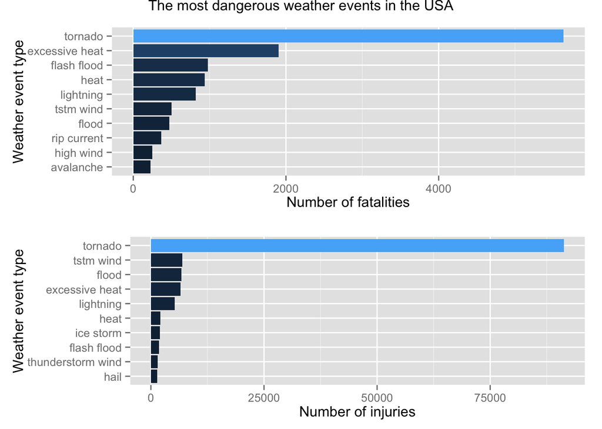

```r
library(ggplot2)
library(gridExtra)
p1 <- ggplot(data=fatal_events,
             aes(x=reorder(EVTYPE, fatalities), y=fatalities, fill=fatalities)) +
    geom_bar(stat="identity") +
    coord_flip() +
    ylab("Number of fatalities") +
    xlab("Weather event type") +
    theme(legend.position="none")

p2 <- ggplot(data=injury_events,
             aes(x=reorder(EVTYPE, injuries), y=injuries, fill=injuries)) +
    geom_bar(stat="identity") +
    coord_flip() +
    ylab("Number of injuries") +
    xlab("Weather event type") +
    theme(legend.position="none")

grid.arrange(p1, p2, main="The most dangerous weather events in the USA")
```

## Economic impact of weather events

The following plot shows the most economic difficult events (property damage, crop damage)

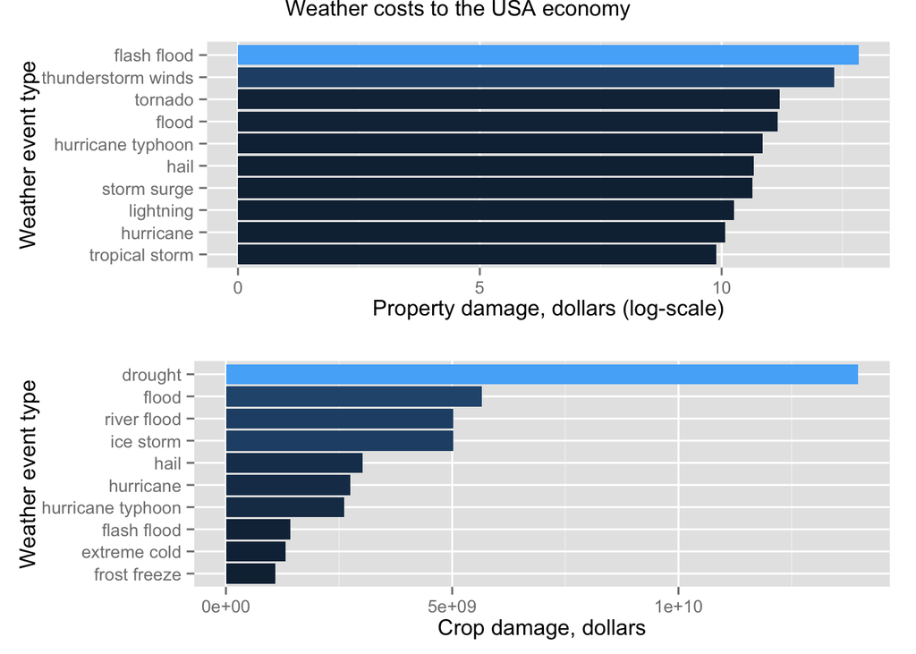

```r
library(ggplot2)
library(gridExtra)
# Set the levels in order
p1 <- ggplot(data=prop_dmg_events,
             aes(x=reorder(EVTYPE, prop_dmg), y=log10(prop_dmg), fill=prop_dmg )) +
    geom_bar(stat="identity") +
    coord_flip() +
    xlab("Weather event type") +
    ylab("Property damage, dollars (log-scale)") +
    theme(legend.position="none")

p2 <- ggplot(data=crop_dmg_events,
             aes(x=reorder(EVTYPE, crop_dmg), y=crop_dmg, fill=crop_dmg)) +
    geom_bar(stat="identity") +
    coord_flip() +
    xlab("Weather event type") +
    ylab("Crop damage, dollars") +
    theme(legend.position="none")

grid.arrange(p1, p2, main="Weather costs to the USA economy")
```

Flash floods and thunderstorm winds cost the most property damages. Also floods and hails cost a lot of money.